# K-means_Clustering

|  | customer_unique_id | Monetary | frequency | review_score_mean | payment_type_mode | product_w_mean | product_mode | recently |
| --- | --- | --- | --- | --- | --- | --- | --- | --- |
| 0 | 0000366f3b9a7992bf8c76cfdf3221e2 | 141.90 | 1 | 5.0 | credit_card | 1500.0 | bed_bath_table | 111 |
| 1 | 0000b849f77a49e4a4ce2b2a4ca5be3f | 27.19 | 1 | 4.0 | credit_card | 375.0 | health_beauty | 113 |

### Clustering avec les données RFM

#### Standarisation des données

```
array([[1.29811155e-03, 0.00000000e+00, 1.55680224e-01],
       [2.48736102e-04, 0.00000000e+00, 1.58485273e-01],
       [7.88746846e-04, 0.00000000e+00, 7.51753156e-01],
       ...,
       [1.02879228e-03, 0.00000000e+00, 7.95231417e-01],
       [1.22300587e-03, 0.00000000e+00, 1.65497896e-01],
       [6.54636097e-04, 0.00000000e+00, 6.76016830e-01]])
```

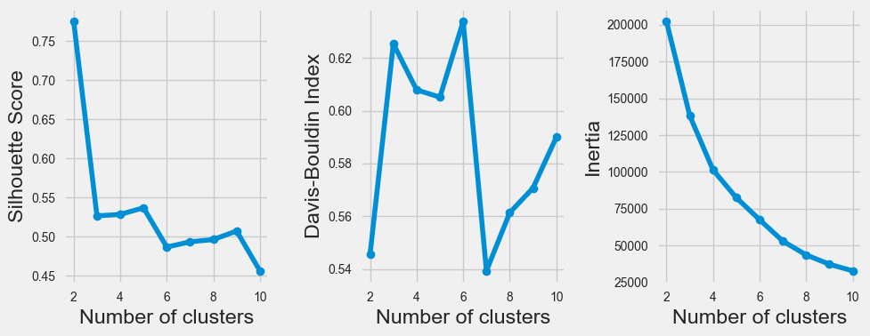

#### * Le pic le plus élevé de la courbe du Silhouette_score représente le nb_cluster optimal qui correspond à la meilleure séparation entre les clusters (nb_clusters = 2) * En ce qui concerne le Davis-Bouldin, le coude le plus bas correspond au nombre optimal de clusters (7). * Selon l'approche de l'inertie, le nb_clusters optimale correspond au coude où l'évolution de l'inertie diminue plus lentement. ** En faisant des recoupement sur les trois approches, on peut choisir comme nombre de cluster optimal = 7

### Visualisation détaillée du graph de silhouette avec yellowbrick

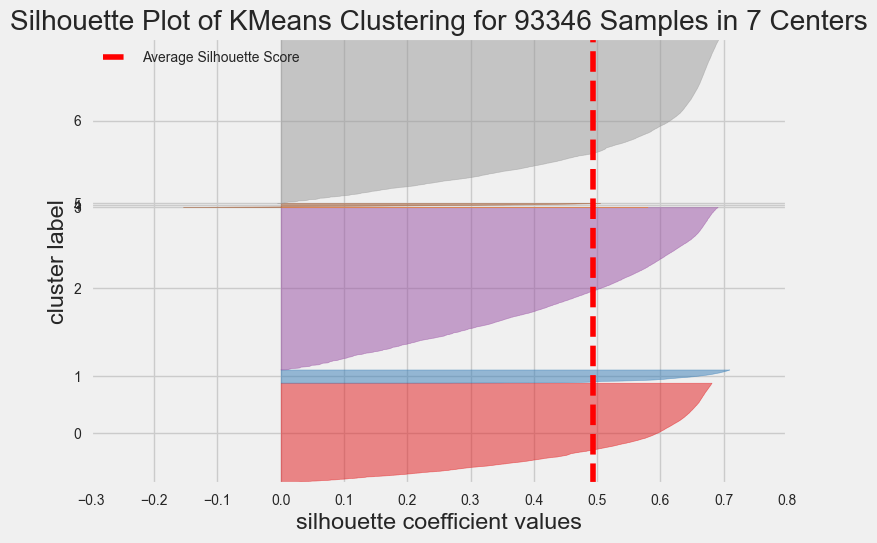

|  | customer_unique_id | Monetary | frequency | review_score_mean | payment_type_mode | product_w_mean | product_mode | recently |
| --- | --- | --- | --- | --- | --- | --- | --- | --- |
| 0 | 0000366f3b9a7992bf8c76cfdf3221e2 | 141.90 | 1 | 5.0 | credit_card | 1500.0 | bed_bath_table | 111 |
| 1 | 0000b849f77a49e4a4ce2b2a4ca5be3f | 27.19 | 1 | 4.0 | credit_card | 375.0 | health_beauty | 113 |
| 2 | 0000f46a3911fa3c0805444483337064 | 86.22 | 1 | 3.0 | credit_card | 1500.0 | stationery | 536 |
| 3 | 0000f6ccb0745a6a4b88665a16c9f078 | 43.62 | 1 | 4.0 | credit_card | 150.0 | telephony | 320 |
| 4 | 0004aac84e0df4da2b147fca70cf8255 | 196.89 | 1 | 5.0 | credit_card | 6050.0 | telephony | 287 |

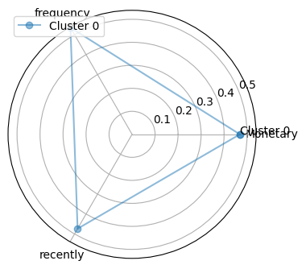

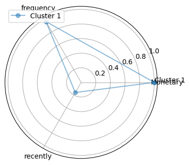

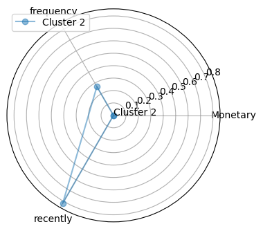

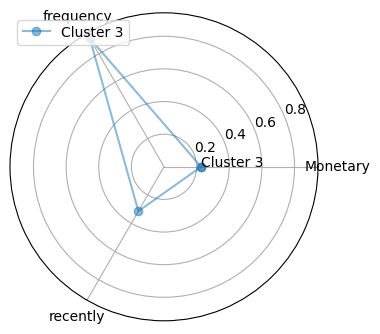

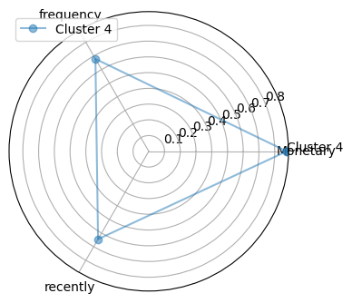

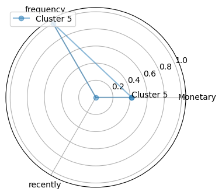

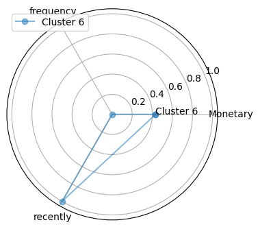